# Lizard Lake

##### Nitrogen Ammonia Total (fl. conc.)

—

No simple [BC Aquatic Life Guideline](https://www2.gov.bc.ca/gov/content?id=044DD64C7E24415D83D07430964113C9) available for this parameter

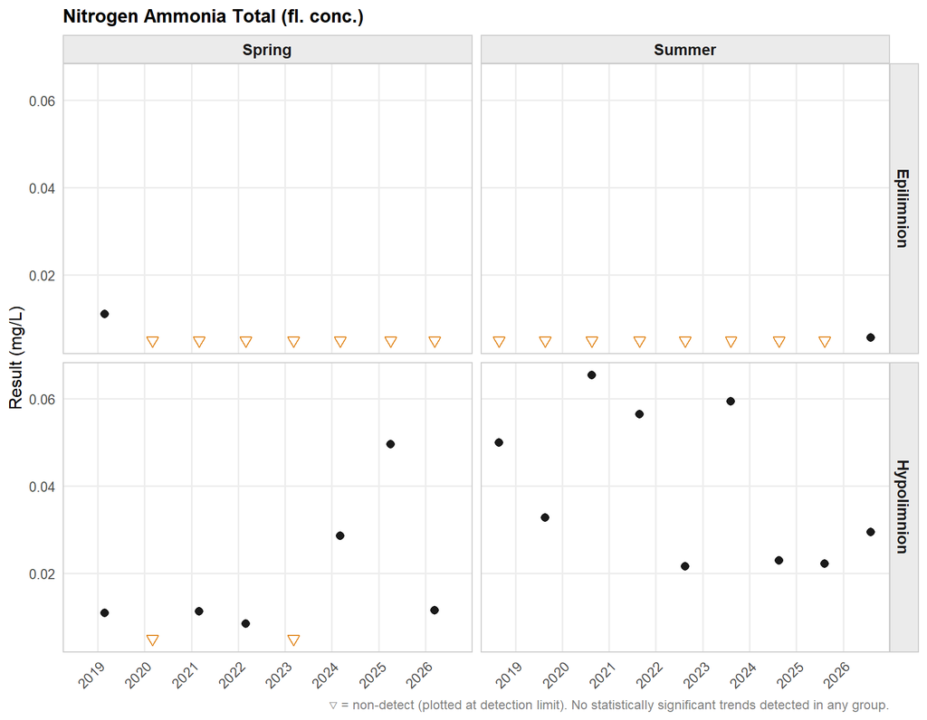

**▶ Summary Statistics Table**

**Lizard Lake**

Nitrogen Ammonia Total (fl. conc.) (mg/L)

| N | Min<sup>1</sup> | 10th %ile | Median | Mean | 90th %ile | Max |
| --- | --- | --- | --- | --- | --- | --- |
| Hypolimnion — Summer |  |  |  |  |  |  |
| 9 | 0.0216 | 0.0221 | 0.0328 | 0.04 | 0.0606 | 0.0654 |
| Hypolimnion — Spring |  |  |  |  |  |  |
| 8 | <0.005 | <0.005 | 0.0112 | 0.0163 | 0.0349 | 0.0496 |
| Epilimnion — Summer |  |  |  |  |  |  |
| 9 | <0.005 | <0.005 | <0.005 | 0.00507 | 0.00512 | 0.0056 |
| Epilimnion — Spring |  |  |  |  |  |  |
| 8 | <0.005 | <0.005 | <0.005 | 0.00575 | 0.0068 | 0.011 |

<sup>1</sup> < indicates non-detect; value shown is the detection limit.

##### Nitrogen Kjel.Tot(N) (fl. conc.)

—

No simple [BC Aquatic Life Guideline](https://www2.gov.bc.ca/gov/content?id=044DD64C7E24415D83D07430964113C9) available for this parameter

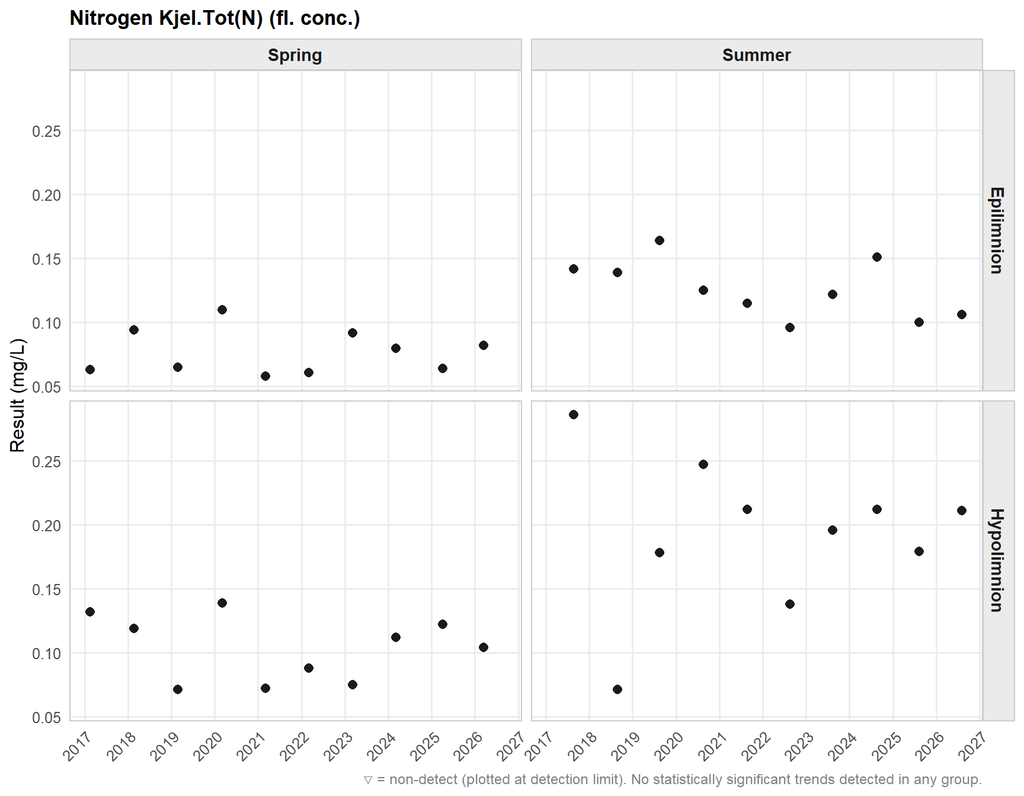

**▶ Summary Statistics Table**

**Lizard Lake**

Nitrogen Kjel.Tot(N) (fl. conc.) (mg/L)

| N | Min<sup>1</sup> | 10th %ile | Median | Mean | 90th %ile | Max |
| --- | --- | --- | --- | --- | --- | --- |
| Hypolimnion — Summer |  |  |  |  |  |  |
| 10 | 0.071 | 0.131 | 0.204 | 0.193 | 0.251 | 0.286 |
| Hypolimnion — Spring |  |  |  |  |  |  |
| 10 | 0.071 | 0.0719 | 0.108 | 0.103 | 0.133 | 0.139 |
| Epilimnion — Summer |  |  |  |  |  |  |
| 10 | 0.096 | 0.0996 | 0.124 | 0.126 | 0.152 | 0.164 |
| Epilimnion — Spring |  |  |  |  |  |  |
| 10 | 0.058 | 0.0607 | 0.0725 | 0.0769 | 0.0956 | 0.11 |

<sup>1</sup> < indicates non-detect; value shown is the detection limit.

##### Nitrogen Organic-Total (fl. conc.)

—

No simple [BC Aquatic Life Guideline](https://www2.gov.bc.ca/gov/content?id=044DD64C7E24415D83D07430964113C9) available for this parameter

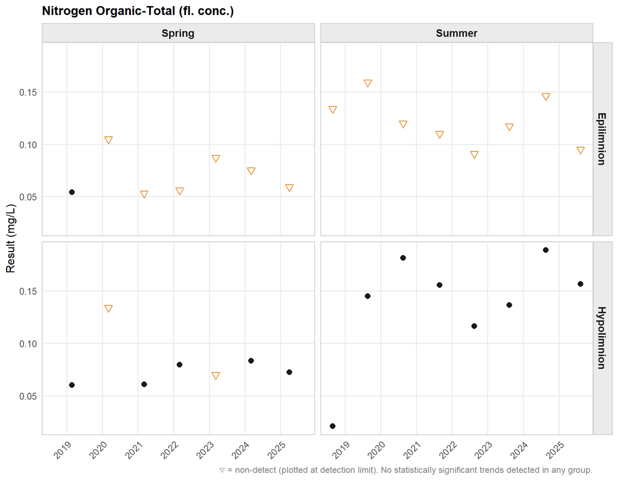

**▶ Summary Statistics Table**

**Lizard Lake**

Nitrogen Organic-Total (fl. conc.) (mg/L)

| N | Min<sup>1</sup> | 10th %ile | Median | Mean | 90th %ile | Max |
| --- | --- | --- | --- | --- | --- | --- |
| Hypolimnion — Summer |  |  |  |  |  |  |
| 8 | <0.021 | 0.0878 | 0.15 | 0.138 | 0.184 | 0.189 |
| Hypolimnion — Spring |  |  |  |  |  |  |
| 7 | 0.06 | 0.0604 | 0.0724 | 0.08 | 0.104 | 0.134 |
| Epilimnion — Summer |  |  |  |  |  |  |
| 8 | 0.091 | 0.0938 | 0.118 | 0.122 | 0.15 | 0.159 |
| Epilimnion — Spring |  |  |  |  |  |  |
| 7 | <0.053 | 0.0536 | 0.059 | 0.0699 | 0.0942 | 0.105 |

<sup>1</sup> < indicates non-detect; value shown is the detection limit.

##### Nitrogen Total (fl. conc.)

—

No simple [BC Aquatic Life Guideline](https://www2.gov.bc.ca/gov/content?id=044DD64C7E24415D83D07430964113C9) available for this parameter

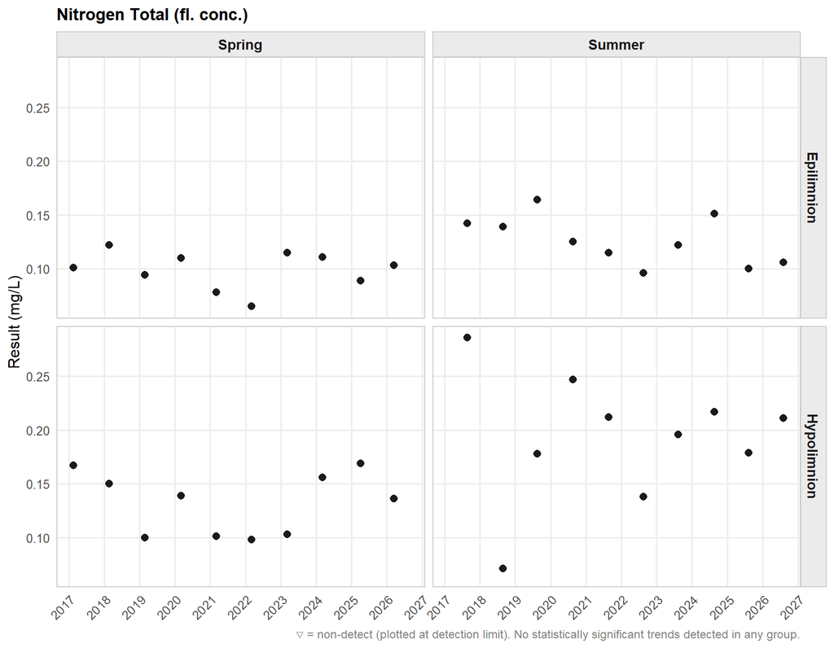

**▶ Summary Statistics Table**

**Lizard Lake**

Nitrogen Total (fl. conc.) (mg/L)

| N | Min<sup>1</sup> | 10th %ile | Median | Mean | 90th %ile | Max |
| --- | --- | --- | --- | --- | --- | --- |
| Hypolimnion — Summer |  |  |  |  |  |  |
| 10 | 0.071 | 0.131 | 0.204 | 0.194 | 0.251 | 0.286 |
| Hypolimnion — Spring |  |  |  |  |  |  |
| 10 | 0.098 | 0.0998 | 0.138 | 0.132 | 0.167 | 0.169 |
| Epilimnion — Summer |  |  |  |  |  |  |
| 10 | 0.096 | 0.0996 | 0.124 | 0.126 | 0.152 | 0.164 |
| Epilimnion — Spring |  |  |  |  |  |  |
| 10 | 0.065 | 0.0767 | 0.102 | 0.0988 | 0.116 | 0.122 |

<sup>1</sup> < indicates non-detect; value shown is the detection limit.

##### Phosphorus Ort.Dis-P (fl. conc.)

—

No simple [BC Aquatic Life Guideline](https://www2.gov.bc.ca/gov/content?id=044DD64C7E24415D83D07430964113C9) available for this parameter

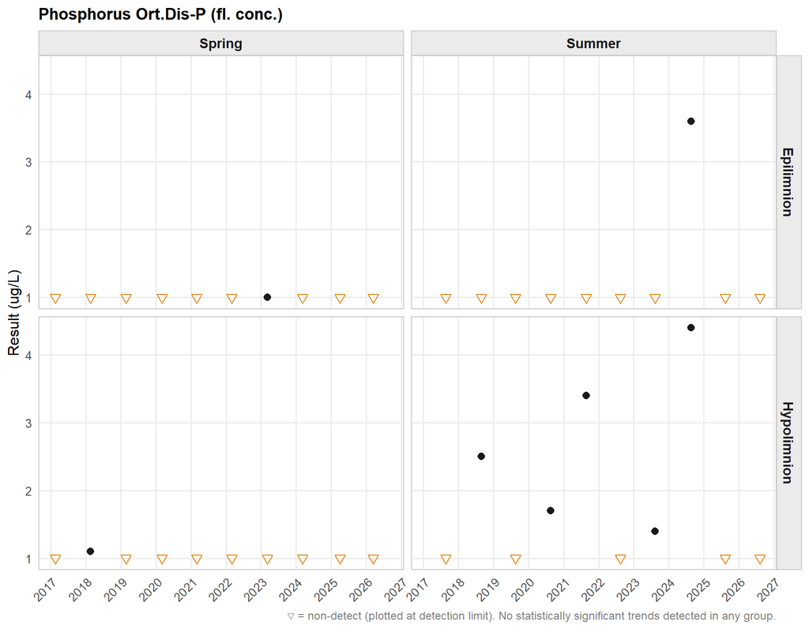

**▶ Summary Statistics Table**

**Lizard Lake**

Phosphorus Ort.Dis-P (fl. conc.) (ug/L)

| N | Min<sup>1</sup> | 10th %ile | Median | Mean | 90th %ile | Max |
| --- | --- | --- | --- | --- | --- | --- |
| Hypolimnion — Summer |  |  |  |  |  |  |
| 10 | <1 | <1 | 1.2 | 1.84 | 3.5 | 4.4 |
| Hypolimnion — Spring |  |  |  |  |  |  |
| 10 | <1 | <1 | <1 | 1.01 | 1.01 | 1.1 |
| Epilimnion — Summer |  |  |  |  |  |  |
| 10 | <1 | <1 | <1 | 1.26 | 1.26 | 3.6 |
| Epilimnion — Spring |  |  |  |  |  |  |
| 10 | <1 | <1 | <1 | <1 | <1 | <1 |

<sup>1</sup> < indicates non-detect; value shown is the detection limit.

##### Phosphorus Total (fl. conc.)

⚠

[BC Aquatic Life Guideline](https://www2.gov.bc.ca/gov/content/environment/air-land-water/water/water-quality/water-quality-guidelines/approved-water-quality-guidelines) · Long-term chronic (Upper Limit) Aquatic Life - Freshwater

≤15 ug/L

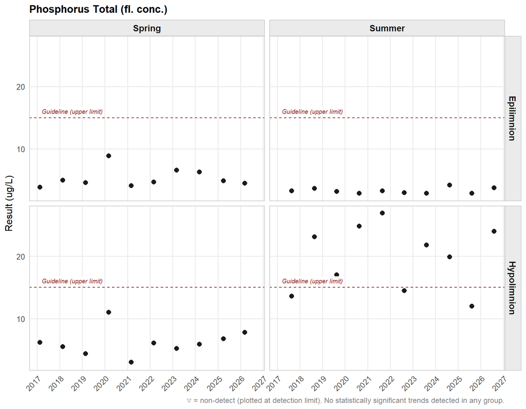

**▶ Summary Statistics Table**

**Lizard Lake**

Phosphorus Total (fl. conc.) (ug/L)

| N | Min<sup>1</sup> | 10th %ile | Median | Mean | 90th %ile | Max<sup>2</sup> |
| --- | --- | --- | --- | --- | --- | --- |
| Hypolimnion — Summer |  |  |  |  |  |  |
| 10 | 12 | 13.4 | 20.8 | 19.8 | 25 | 26.9 |
| Hypolimnion — Spring |  |  |  |  |  |  |
| 10 | 3 | 4.26 | 6 | 6.19 | 8.12 | 11 |
| Epilimnion — Summer |  |  |  |  |  |  |
| 10 | 2.9 | 2.9 | 3.25 | 3.32 | 3.84 | 4.2 |
| Epilimnion — Spring |  |  |  |  |  |  |
| 10 | 3.9 | 4.08 | 4.8 | 5.35 | 6.83 | 8.9 |

<sup>1</sup> < indicates non-detect; value shown is the detection limit.  
<sup>2</sup> Red = this group’s maximum result exceeds the BC Aquatic Life guideline.

##### Phosphorus Total Dissolved (fl. conc.)

—

No simple [BC Aquatic Life Guideline](https://www2.gov.bc.ca/gov/content?id=044DD64C7E24415D83D07430964113C9) available for this parameter

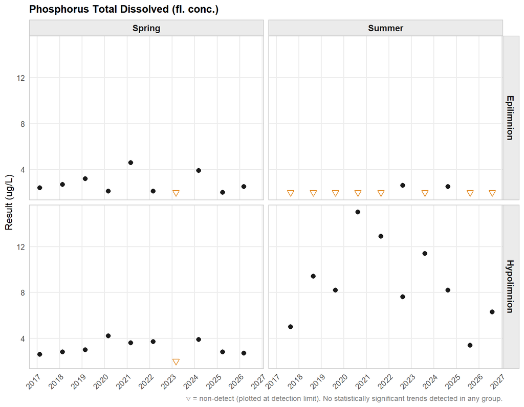

**▶ Summary Statistics Table**

**Lizard Lake**

Phosphorus Total Dissolved (fl. conc.) (ug/L)

| N | Min<sup>1</sup> | 10th %ile | Median | Mean | 90th %ile | Max |
| --- | --- | --- | --- | --- | --- | --- |
| Hypolimnion — Summer |  |  |  |  |  |  |
| 10 | 3.4 | 4.84 | 8.2 | 8.74 | 13.1 | 15 |
| Hypolimnion — Spring |  |  |  |  |  |  |
| 10 | <2 | 2.54 | 2.9 | 3.13 | 3.93 | 4.2 |
| Epilimnion — Summer |  |  |  |  |  |  |
| 10 | <2 | <2 | <2 | 2.11 | 2.51 | 2.6 |
| Epilimnion — Spring |  |  |  |  |  |  |
| 10 | <2 | <2 | 2.45 | 2.75 | 3.97 | 4.6 |

<sup>1</sup> < indicates non-detect; value shown is the detection limit.

##### Silica Reactive Diss (fl. conc.)

—

No simple [BC Aquatic Life Guideline](https://www2.gov.bc.ca/gov/content?id=044DD64C7E24415D83D07430964113C9) available for this parameter

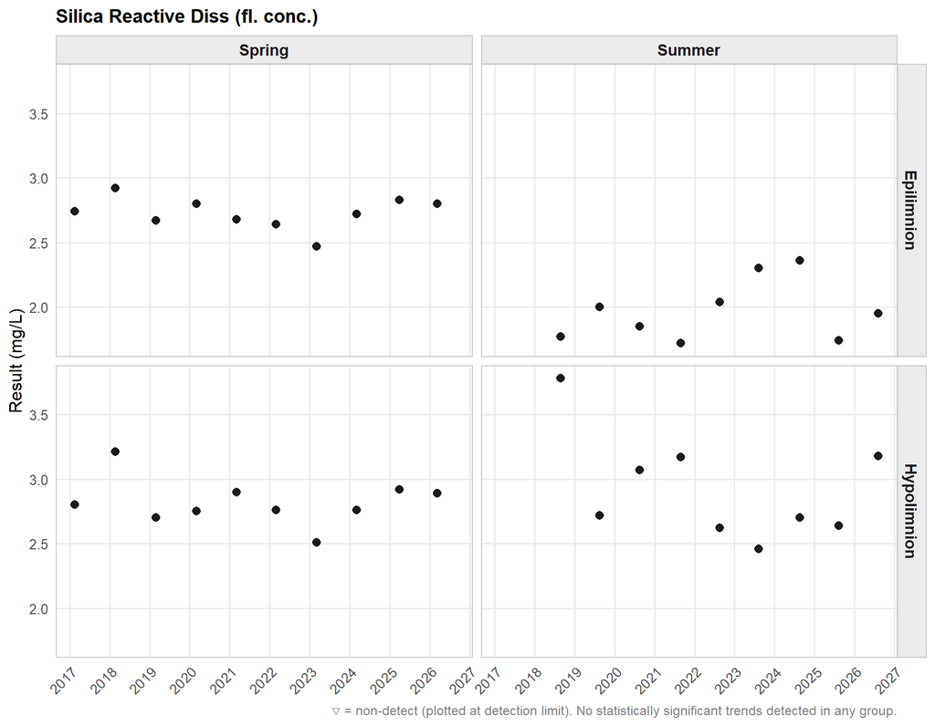

**▶ Summary Statistics Table**

**Lizard Lake**

Silica Reactive Diss (fl. conc.) (mg/L)

| N | Min<sup>1</sup> | 10th %ile | Median | Mean | 90th %ile | Max |
| --- | --- | --- | --- | --- | --- | --- |
| Hypolimnion — Summer |  |  |  |  |  |  |
| 9 | 2.46 | 2.59 | 2.72 | 2.93 | 3.3 | 3.78 |
| Hypolimnion — Spring |  |  |  |  |  |  |
| 10 | 2.51 | 2.68 | 2.78 | 2.82 | 2.95 | 3.21 |
| Epilimnion — Summer |  |  |  |  |  |  |
| 9 | 1.72 | 1.74 | 1.95 | 1.97 | 2.31 | 2.36 |
| Epilimnion — Spring |  |  |  |  |  |  |
| 10 | 2.47 | 2.62 | 2.73 | 2.73 | 2.84 | 2.92 |

<sup>1</sup> < indicates non-detect; value shown is the detection limit.

#### **Metals - Total**

##### Aluminum Total (fl. conc.)

—

No simple [BC Aquatic Life Guideline](https://www2.gov.bc.ca/gov/content?id=044DD64C7E24415D83D07430964113C9) available for this parameter

Dependent on hardness, pH, and Dissolved Organic Carbon

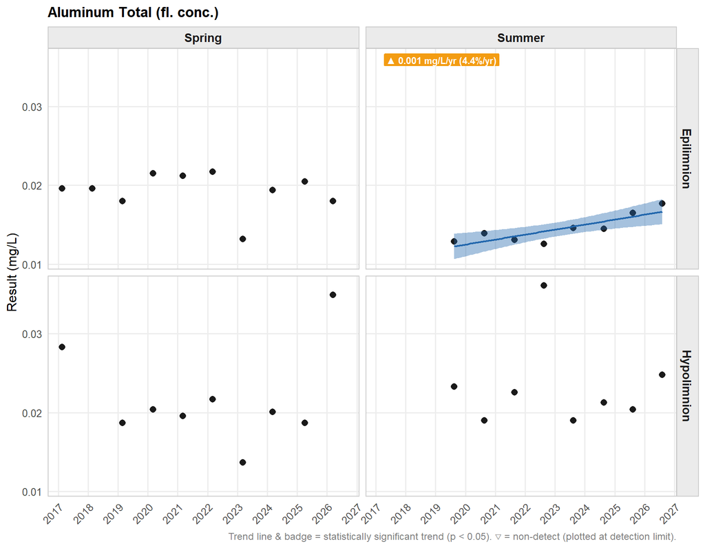

**▶ Summary Statistics Table**

**Lizard Lake**

Aluminum Total (fl. conc.) (mg/L)

| N | Min<sup>1</sup> | 10th %ile | Median | Mean | 90th %ile | Max |
| --- | --- | --- | --- | --- | --- | --- |
| Hypolimnion — Summer |  |  |  |  |  |  |
| 8 | 0.019 | 0.019 | 0.0219 | 0.0233 | 0.0282 | 0.0361 |
| Hypolimnion — Spring |  |  |  |  |  |  |
| 9 | 0.0137 | 0.0177 | 0.0201 | 0.0218 | 0.0296 | 0.0349 |
| Epilimnion — Summer |  |  |  |  |  |  |
| 8 | 0.0126 | 0.0128 | 0.0142 | 0.0145 | 0.0169 | 0.0177 |
| Epilimnion — Spring |  |  |  |  |  |  |
| 10 | 0.0132 | 0.0175 | 0.0196 | 0.0193 | 0.0215 | 0.0217 |

<sup>1</sup> < indicates non-detect; value shown is the detection limit.

##### Antimony Total (fl. conc.)

✓

[BC Aquatic Life Guideline](https://www2.gov.bc.ca/gov/content/environment/air-land-water/water/water-quality/water-quality-guidelines/approved-water-quality-guidelines) · Long-term chronic (Upper Limit) Aquatic Life - Freshwater

≤74 ug/L

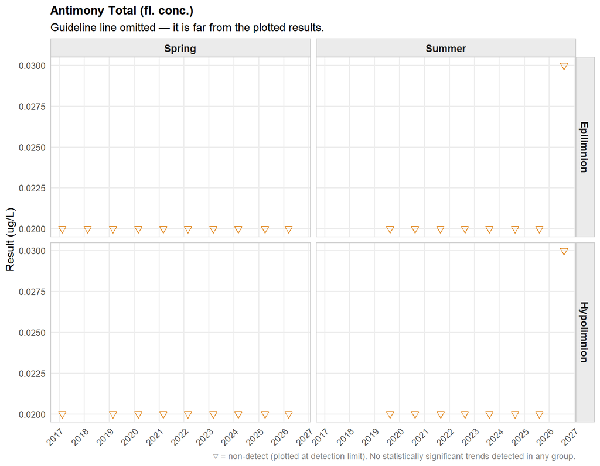

**▶ Summary Statistics Table**

**Lizard Lake**

Antimony Total (fl. conc.) (ug/L)

| N | Min<sup>1</sup> | 10th %ile | Median | Mean | 90th %ile | Max |
| --- | --- | --- | --- | --- | --- | --- |
| Hypolimnion — Summer |  |  |  |  |  |  |
| 8 | <0.02 | <0.02 | <0.02 | 0.0213 | 0.023 | 0.03 |
| Hypolimnion — Spring |  |  |  |  |  |  |
| 9 | <0.02 | <0.02 | <0.02 | <0.02 | <0.02 | <0.02 |
| Epilimnion — Summer |  |  |  |  |  |  |
| 8 | <0.02 | <0.02 | <0.02 | 0.0213 | 0.023 | 0.03 |
| Epilimnion — Spring |  |  |  |  |  |  |
| 10 | <0.02 | <0.02 | <0.02 | <0.02 | <0.02 | <0.02 |

<sup>1</sup> < indicates non-detect; value shown is the detection limit.

##### Arsenic Total (fl. conc.)

✓

[BC Aquatic Life Guideline](https://www2.gov.bc.ca/gov/content/environment/air-land-water/water/water-quality/water-quality-guidelines/approved-water-quality-guidelines) · Long-term chronic (Upper Limit) Aquatic Life - Freshwater

≤5 ug/L

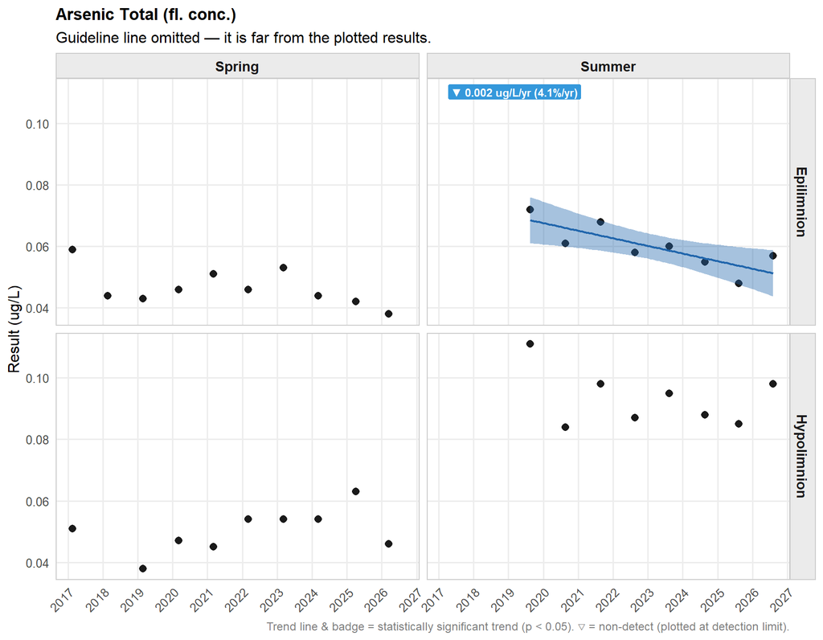

**▶ Summary Statistics Table**

**Lizard Lake**

Arsenic Total (fl. conc.) (ug/L)

| N | Min<sup>1</sup> | 10th %ile | Median | Mean | 90th %ile | Max |
| --- | --- | --- | --- | --- | --- | --- |
| Hypolimnion — Summer |  |  |  |  |  |  |
| 8 | 0.084 | 0.0847 | 0.0915 | 0.0932 | 0.102 | 0.111 |
| Hypolimnion — Spring |  |  |  |  |  |  |
| 9 | 0.038 | 0.0436 | 0.051 | 0.0502 | 0.0558 | 0.063 |
| Epilimnion — Summer |  |  |  |  |  |  |
| 8 | 0.048 | 0.0529 | 0.059 | 0.0599 | 0.0692 | 0.072 |
| Epilimnion — Spring |  |  |  |  |  |  |
| 10 | 0.038 | 0.0416 | 0.045 | 0.0466 | 0.0536 | 0.059 |

<sup>1</sup> < indicates non-detect; value shown is the detection limit.

##### Barium Total (fl. conc.)

✓

[BC Aquatic Life Guideline](https://www2.gov.bc.ca/gov/content/environment/air-land-water/water/water-quality/water-quality-guidelines/approved-water-quality-guidelines) · Long-term chronic (Upper Limit) Aquatic Life - Freshwater

≤1000 ug/L

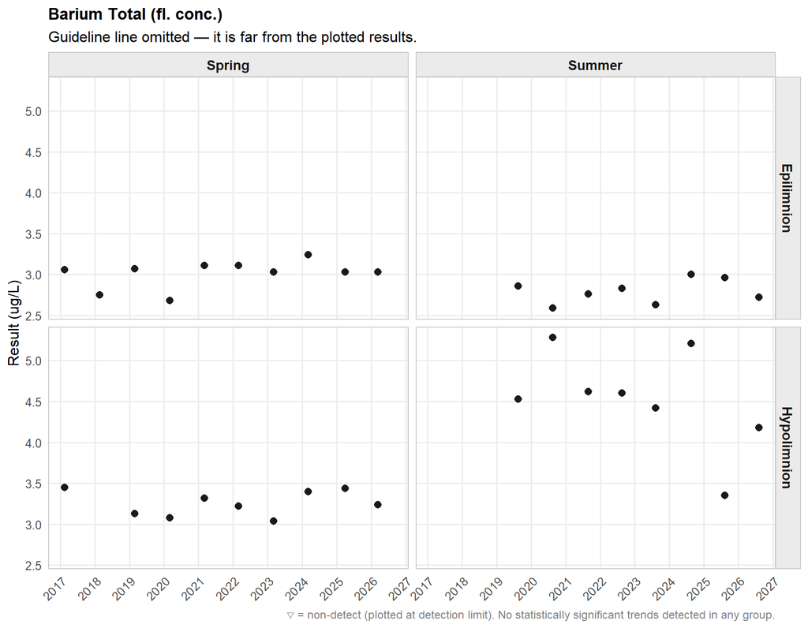

**▶ Summary Statistics Table**

**Lizard Lake**

Barium Total (fl. conc.) (ug/L)

| N | Min<sup>1</sup> | 10th %ile | Median | Mean | 90th %ile | Max |
| --- | --- | --- | --- | --- | --- | --- |
| Hypolimnion — Summer |  |  |  |  |  |  |
| 8 | 3.35 | 3.93 | 4.56 | 4.52 | 5.23 | 5.28 |
| Hypolimnion — Spring |  |  |  |  |  |  |
| 9 | 3.04 | 3.07 | 3.24 | 3.26 | 3.44 | 3.45 |
| Epilimnion — Summer |  |  |  |  |  |  |
| 8 | 2.59 | 2.62 | 2.8 | 2.79 | 2.97 | 3 |
| Epilimnion — Spring |  |  |  |  |  |  |
| 10 | 2.68 | 2.74 | 3.04 | 3.01 | 3.12 | 3.24 |

<sup>1</sup> < indicates non-detect; value shown is the detection limit.

##### Beryllium Total (fl. conc.)

✓

[BC Aquatic Life Guideline](https://www2.gov.bc.ca/gov/content/environment/air-land-water/water/water-quality/water-quality-guidelines/approved-water-quality-guidelines) · Long-term chronic (Upper Limit) Aquatic Life - Freshwater

≤130 ng/L

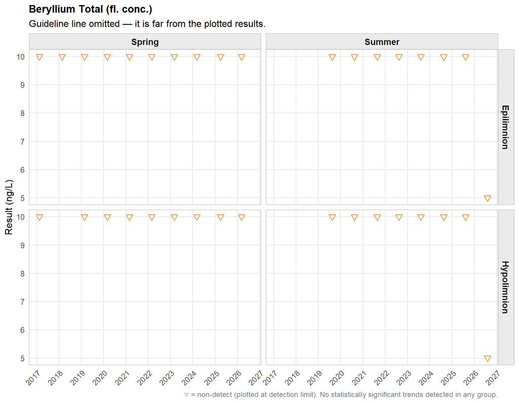

**▶ Summary Statistics Table**

**Lizard Lake**

Beryllium Total (fl. conc.) (ng/L)

| N | Min<sup>1</sup> | 10th %ile | Median | Mean | 90th %ile | Max |
| --- | --- | --- | --- | --- | --- | --- |
| Hypolimnion — Summer |  |  |  |  |  |  |
| 8 | <5 | 8.5 | 10 | 9.38 | 10 | 10 |
| Hypolimnion — Spring |  |  |  |  |  |  |
| 9 | 10 | 10 | 10 | 10 | 10 | 10 |
| Epilimnion — Summer |  |  |  |  |  |  |
| 8 | <5 | 8.5 | 10 | 9.38 | 10 | 10 |
| Epilimnion — Spring |  |  |  |  |  |  |
| 10 | 10 | 10 | 10 | 10 | 10 | 10 |

<sup>1</sup> < indicates non-detect; value shown is the detection limit.

##### Bismuth Total (fl. conc.)

—

No simple [BC Aquatic Life Guideline](https://www2.gov.bc.ca/gov/content?id=044DD64C7E24415D83D07430964113C9) available for this parameter

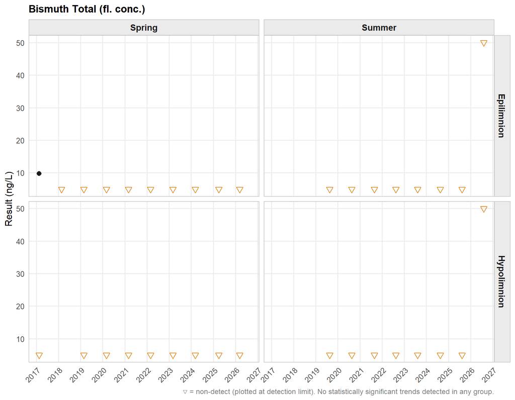

**▶ Summary Statistics Table**

**Lizard Lake**

Bismuth Total (fl. conc.) (ng/L)

| N | Min<sup>1</sup> | 10th %ile | Median | Mean | 90th %ile | Max |
| --- | --- | --- | --- | --- | --- | --- |
| Hypolimnion — Summer |  |  |  |  |  |  |
| 8 | <5 | <5 | <5 | 10.6 | 18.5 | 50 |
| Hypolimnion — Spring |  |  |  |  |  |  |
| 9 | <5 | <5 | <5 | <5 | <5 | <5 |
| Epilimnion — Summer |  |  |  |  |  |  |
| 8 | <5 | <5 | <5 | 10.6 | 18.5 | 50 |
| Epilimnion — Spring |  |  |  |  |  |  |
| 10 | <5 | <5 | <5 | 5.48 | 5.48 | 9.8 |

<sup>1</sup> < indicates non-detect; value shown is the detection limit.